# Week2 Reproducible Research

Walter Steenekamp

09 July 2016

## Load and preprocess

- Load and preprocess the data, also here any additional libraries is loaded, the activity.csv where the raw data is stored was copied in my working directory.

```r
library(dplyr)
activityDF <- read.csv("activity.csv")

#making the date column in a more usable and comfortable format
activityDF <- activityDF %>% mutate(date = as.POSIXct(date))
```

## Total number of steps taken per day

We first calculate the total steps per day, then view the average in a histogram, the two lines, red and blue, shows mean and median respectively.

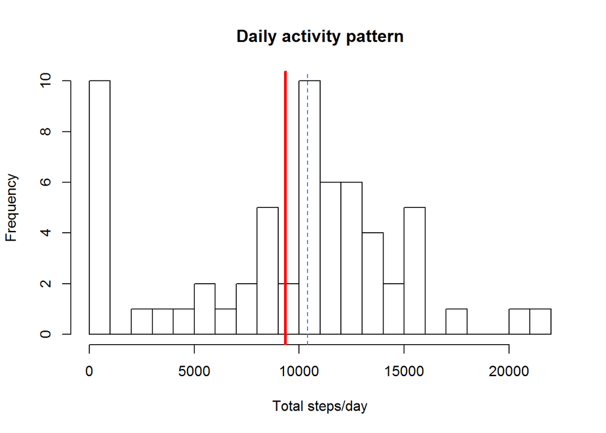

```r
#group by date and sum the steps to get a total for date
activityDF_daily <- activityDF %>% group_by(date) %>% summarise(count = sum(steps, na.rm = TRUE), avg = mean(steps, na.rm = TRUE)) %>% arrange(date)

# draw the histogram
hist(activityDF_daily$count, breaks = 30, xlab= "Total steps/day", main  = "Daily activity pattern")
abline(v = mean(activityDF_daily$count, na.rm = TRUE), col = "red", lwd = 3)
abline(v = median(activityDF_daily$count, na.rm = TRUE), col = "royalBlue", lwd = 1, lty = "dashed")
```

From the graph of daily number of steps the red vertical line shows where the mean is wheras the blue dashed line shows the median value on the graph.

- Lets calculate the Mean and Median now and print it:

```r
#mean
print(mean(activityDF_daily$count, na.rm = TRUE))
```

```
## [1] 9354.23
```

```r
#medain
print(median(activityDF_daily$count, na.rm = TRUE))
```

```
## [1] 10395
```

## Average daily activity pattern

- The graph below shows the average steps taken per 5 minute interval, the red vertical line shows the max interval on average over all days in the test set.

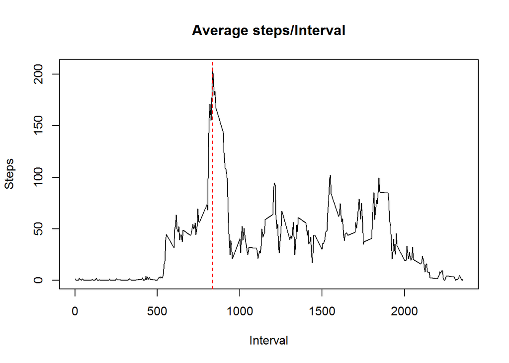

```r
# First it is necessary to summarise the data according to the intervals
activityDF_intervals <- activityDF %>% group_by(interval) %>% summarise(cnt = sum(steps, na.rm = TRUE), avg = mean(steps, na.rm = TRUE))

# now we can plot this:
plot(x = activityDF_intervals$interval, y = activityDF_intervals$avg, type = "l", xlab = "Interval", ylab = "Steps", main = "Average steps/Interval")
abline(v = as.numeric(activityDF_intervals[activityDF_intervals$avg == max(activityDF_intervals$avg),1]), col = "red", lty = "dashed")
```

```r
#lets get the interval with the highes number of steps in 5 minutes
print(activityDF_intervals[activityDF_intervals$avg == max(activityDF_intervals$avg),c(1,3)])
```

```
## Source: local data frame [1 x 2]
##
##   interval      avg
##      (int)    (dbl)
## 1      835 206.1698
```

The interval 835, as shown in the plot above, has got the most steps on average across all days for a 5 minute interval at an average of 206 steps.

## Imputing missing values

- I am using the *mice* package here that assists with imputing values, make sure you have it installed.

```r
library(mice)
#only use the int columns here for the imputation, also there are no missing values in the dates
activityDF_sub <- activityDF[,c(1,3)]

#run the imputing function
activity_imp <- mice(activityDF_sub, m=2, maxit = 20, method = "pmm", seed = 80)
```

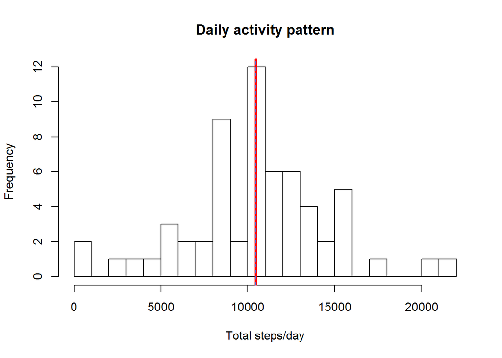

```r
activity_imp_done <- complete(activity_imp, 2)
#add the date variable back:
activity_imp_done <- cbind(activity_imp_done, activityDF$date)

names(activity_imp_done)[names(activity_imp_done)=="activityDF$date"] <- "date"

# re-calculate daily activity patern with amended data
steps_daily <- activity_imp_done %>% group_by(date) %>% summarise(count = sum(steps, na.rm = TRUE), avg = mean(steps, na.rm = TRUE)) %>% arrange(date)

#draw a histogram of the results

hist(steps_daily$count, breaks = 30, xlab= "Total steps/day", main  = "Daily activity pattern")
abline(v = mean(steps_daily$count, na.rm = TRUE), col = "red", lwd = 3)
abline(v = median(steps_daily$count, na.rm = TRUE), col = "royalBlue", lwd = 1, lty = "dashed")
```

```r
#what is our mean and medians now

print(mean(steps_daily$count, na.rm = TRUE))
```

```
## [1] 10458.77
```

```r
print(median(steps_daily$count, na.rm = TRUE))
```

```
## [1] 10439
```

The median has stayed very much the same, the mean is now slightly larger, you can also see that the first bar(left most column) in the non-imputed histogram had a high frequency, the histogram with the imputed values represents more of a bell curve.

## Weekend and Weekday activity paterns.

Before we start it is important to note that here I used the *Chron* package, make sure you have it installed, the version I used can be found at : [link](https://cran.rstudio.com/bin/windows/contrib/3.2/chron_2.3-47.zip)

```r
library(chron)
```

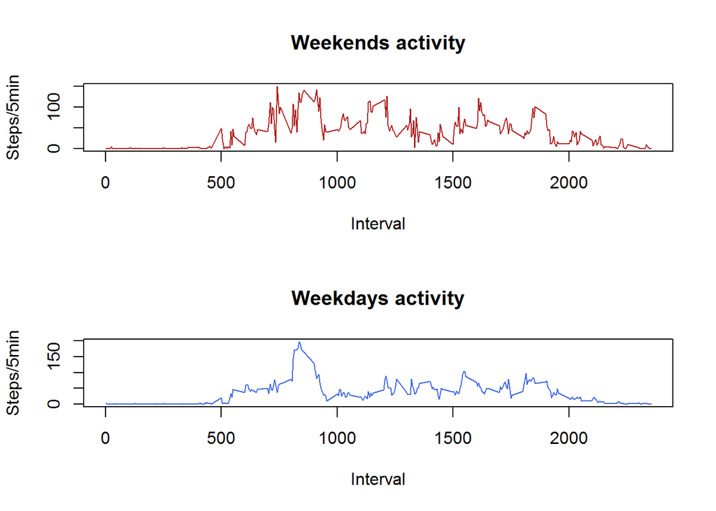

```r
# create an additional column that is true if date is a weekend and false otherwise
DayType <- activity_imp_done %>% mutate(isWeekend =  is.weekend(date))
wkends <- filter(DayType, isWeekend)
wkdays <- filter(DayType, !isWeekend)

mean_week <- wkends %>% group_by(interval) %>%  summarise(avg=mean(steps))  %>% arrange(interval)
mean_wdays <-  wkdays %>% group_by(interval) %>%  summarise(avg=mean(steps)) %>% arrange(interval)

#draw the seperate averages
par(mfrow =  c(2,1))
plot(mean_week$interval, mean_week$avg, type = "l",  ylab =  "Steps/5min", xlab = "Interval", main = "Weekends activity",  col  = "firebrick")
plot(mean_wdays$interval, mean_wdays$avg, type  =  "l", ylab = "Steps/5min", xlab = "Interval",  main  = "Weekdays activity", col = "royalblue")
```

During the week there is a high spike at around intervals 830 - 900, whereas the weekends shows a more linear activity patern.